# Modeling and prediction for movies

## Setup

### Load packages

```r
library(ggplot2)
library(dplyr)
library(statsr)
```

### Load data

```r
load("movies.Rdata")
```

## Part 1: Data

The data set is comprised of 651 randomly sampled movies produced and released before 2016. Since random sampling is used for data collection the associations and relations observed in the sample can be generalized to the population at large There is no random assignment so no causal relationship can be determined from this sample

## Part 2: Research question

Is there an association between audience rating and genre of the movie?

This is an interesting question since at the end of the day commercial success of the movie depends on the audience, which can be best represented by audience score

## Part 3: Exploratory data analysis

```r
#average raitng across genre
movies %>%
  filter(!is.na(genre) & !is.na(audience_score)) %>%
  group_by(genre) %>%
  summarise(avg_rating=mean(audience_score))
```

```
## # A tibble: 11 × 2
##                        genre avg_rating
##                       <fctr>      <dbl>
## 1         Action & Adventure   53.78462
## 2                  Animation   62.44444
## 3  Art House & International   64.00000
## 4                     Comedy   52.50575
## 5                Documentary   82.75000
## 6                      Drama   65.34754
## 7                     Horror   45.82609
## 8  Musical & Performing Arts   80.16667
## 9         Mystery & Suspense   55.94915
## 10                     Other   66.68750
## 11 Science Fiction & Fantasy   50.88889
```

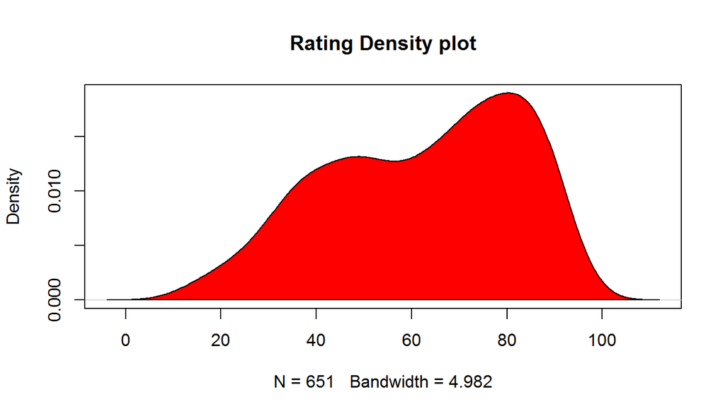

```r
#Density plot for imdb ratings
Rating_density<-(density(movies$audience_score,na.rm=T))
plot(Rating_density,"Rating Density plot")
polygon(Rating_density,col="red")
```

As we can see the distribution is not normal. In order to apply any inferential technique when distribution is not exactly normal we need minimum 30 observations for all levels of a categorical variable

```r
#All genres with entries more than 30
movies %>%
  filter(!is.na(genre) & !is.na(audience_score)) %>%
  group_by(genre) %>%
  summarise(cnt=n()) %>%
  filter(cnt>30)
```

```
## # A tibble: 5 × 2
##                genre   cnt
##               <fctr> <int>
## 1 Action & Adventure    65
## 2             Comedy    87
## 3        Documentary    52
## 4              Drama   305
## 5 Mystery & Suspense    59
```

```r
#Removing genres with very less number of entries
Genre_rat<-movies %>%
  filter(!is.na(genre) & !is.na(imdb_rating) & (genre=="Action & Adventure"
        |  genre=="Drama" |   genre=="Mystery & Suspense"
         | genre=="Comedy" | genre=="Documentary") )

Genre_rat$genre <- factor(Genre_rat$genre)
```

We keep only those genres which have number of observation more than 30 in a new data frame and check the mean audience rating for these levels of genre

```r
Genre_rat %>%
  filter(!is.na(genre) & !is.na(audience_score)) %>%
  group_by(genre) %>%
  summarise(avg_rating=mean(audience_score))
```

```
## # A tibble: 5 × 2
##                genre avg_rating
##               <fctr>      <dbl>
## 1 Action & Adventure   53.78462
## 2             Comedy   52.50575
## 3        Documentary   82.75000
## 4              Drama   65.34754
## 5 Mystery & Suspense   55.94915
```

We can use ANOVA to answer the question that whether difference in mean among the genres that we just saw is statistically significant by using the null hypothesis that there is no difference between mean across genres

However we will need to first verify the conditions require for ANOVA

1.Independence:

a.Within Groups: Since this a random sample it can be said that every successive observation in the sample is independent of the previous observation

2. Among groups: Secondly,different genres are independent of each other it implies the independence among the groups

2.Normality

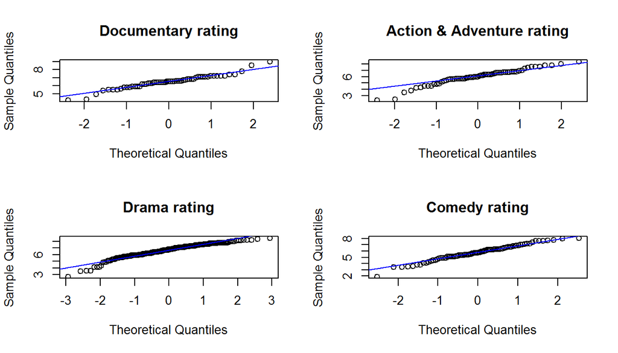

```r
par(mfrow = c(2,2))
qqnorm(Genre_rat$imdb_rating[Genre_rat$genre == "Mystery & Suspense"],
       main = "Documentary rating")
qqline(Genre_rat$imdb_rating[Genre_rat$genre == "Mystery & Suspense"],
       col = 'blue')

qqnorm(Genre_rat$imdb_rating[Genre_rat$genre == "Action & Adventure"],
       main = "Action & Adventure rating")
qqline(Genre_rat$imdb_rating[Genre_rat$genre == "Action & Adventure"],
       col = 'blue')

qqnorm(Genre_rat$imdb_rating[Genre_rat$genre == "Drama"],
       main = "Drama rating")
qqline(Genre_rat$imdb_rating[Genre_rat$genre == "Drama"],
       col = 'blue')

qqnorm(Genre_rat$imdb_rating[Genre_rat$genre == "Comedy"],
       main = "Comedy rating")
qqline(Genre_rat$imdb_rating[Genre_rat$genre == "Comedy"],
       col = 'blue')
```

As we can see all the plots are close to the normal line and any skewness can mitigated since each group is of size greater than 30

3.Equal variance among group

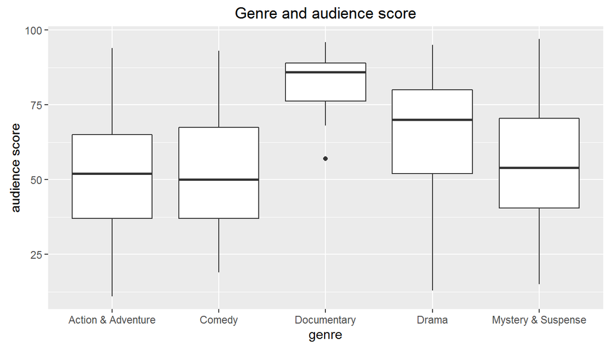

```r
ggplot(data=Genre_rat,aes(x=genre,y=audience_score)) +geom_boxplot()+
  ggtitle("Genre and audience score") +
  labs(y="audience score")
```

As can be seen except documentary every other genre have almost same variability So we can use ANOVA to answer our question that whether average audience score statistically differs across genre

```r
inference(y =audience_score,x = genre, data =Genre_rat,statistic = "mean",
type = "ht",null = 0, alternative = "greater",method = "theoretical")
```

```
## Response variable: numerical
## Explanatory variable: categorical (5 levels)
## n_Action & Adventure = 65, y_bar_Action & Adventure = 53.7846, s_Action & Adventure = 19.7551
## n_Comedy = 87, y_bar_Comedy = 52.5057, s_Comedy = 19.245
## n_Documentary = 52, y_bar_Documentary = 82.75, s_Documentary = 8.42
## n_Drama = 305, y_bar_Drama = 65.3475, s_Drama = 18.5418
## n_Mystery & Suspense = 59, y_bar_Mystery & Suspense = 55.9492, s_Mystery & Suspense = 19.2519
##
## ANOVA:
##            df      Sum_Sq   Mean_Sq       F  p_value
## genre       4  39938.2549 9984.5637 30.1481 < 0.0001
## Residuals 563 186456.4899  331.1838
## Total     567 226394.7447
##
## Pairwise tests - t tests with pooled SD:
##                group1             group2   p.value
## 1              Comedy Action & Adventure 6.684e-01
## 2         Documentary Action & Adventure 1.121e-16
## 3               Drama Action & Adventure 4.122e-06
## 4  Mystery & Suspense Action & Adventure 5.086e-01
## 6         Documentary             Comedy 6.958e-20
## 7               Drama             Comedy 1.071e-08
## 8  Mystery & Suspense             Comedy 2.624e-01
## 11              Drama        Documentary 3.843e-10
## 12 Mystery & Suspense        Documentary 4.552e-14
## 16 Mystery & Suspense              Drama 3.079e-04
```

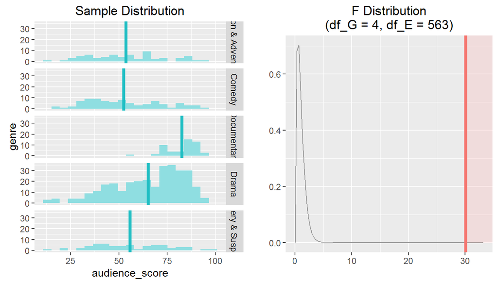

With an overall p-value of less than 0.0001 we can answer the research question that:

“Mean audience score does indeed statistically differ across genre”"

This apply for all pairwise combination of genre except Combination of Action & Adventure,Mystery & Suspense & comedy which can be explained since in real world generally thriller movies do have action in them

## Part 4: Modeling

```r
str(movies$thtr_rel_year)
```

```
##  num [1:651] 2013 2001 1996 1993 2004 ...
```

```r
str(movies$thtr_rel_month)
```

```
##  num [1:651] 4 3 8 10 9 1 1 11 9 3 ...
```

```r
str(movies$thtr_rel_day)
```

```
##  num [1:651] 19 14 21 1 10 15 1 8 7 2 ...
```

```r
str(movies$dvd_rel_day)
```

```
##  num [1:651] 30 28 21 6 19 20 18 2 21 14 ...
```

```r
str(movies$dvd_rel_month)
```

```
##  num [1:651] 7 8 8 11 4 4 2 3 1 8 ...
```

```r
str(movies$dvd_rel_year)
```

```
##  num [1:651] 2013 2001 2001 2001 2005 ...
```

As we can see the day,month and year variable for both theatre and dvd release are numeric while it should be a factor since all of them are categorical variable. So, converting all of them to factor

```r
movies$thtr_rel_year<-as.factor(movies$thtr_rel_year)
movies$thtr_rel_month<-as.factor(movies$thtr_rel_month)
movies$thtr_rel_day<-as.factor(movies$thtr_rel_day)
movies$dvd_rel_day<-as.factor(movies$dvd_rel_day)
movies$dvd_rel_month<-as.factor(movies$dvd_rel_month)
movies$dvd_rel_year<-as.factor(movies$dvd_rel_year)
```

First we will create a new variable weekday variable which contains the day of movie or dvd release since release day may also affect the movie ratings

```r
#creating weekday variable for theatre release
movies$thtr_rel_date <- as.Date(with(movies, paste(thtr_rel_year,
                                                   thtr_rel_month, thtr_rel_day,sep="-")), "%Y-%m-%d")

movies$thtr_weekday<-weekdays(as.Date(movies$thtr_rel_date,"%Y-%m-%d"))
movies$thtr_weekday<-as.factor(movies$thtr_weekday)

#creating weekday variable for theatre release
movies$dvd_rel_date <- as.Date(with(movies, paste(dvd_rel_year,
                                                   dvd_rel_month, dvd_rel_day,sep="-")), "%Y-%m-%d")

movies$dvd_weekday<-weekdays(as.Date(movies$dvd_rel_date,"%Y-%m-%d"))
movies$dvd_weekday<-as.factor(movies$dvd_weekday)
```

Now we clean current data set to remove the variables which are irrelevant/can’t be used for creation of model like:

1. Name of the movie since each movie has unique name and no relationship can be established using it

2.Year of theatre and dvd release: Since this variable if present in model will not be able to predict for any level which is not present in the dataset like year 2016 which will be the case for the latest movies

3.Best picture nomination and win: For the latest movies oscar nominations have not been announced hence there can be no conclusive yes or no value for this variable

4.Removing actor one to five : Same reason as second. An actor/actress not present in data set will not give result when use for prediction

```r
# Removing all irrelevant variables as mentioned above

movies<-movies[,-c(1,7,10,19,20,25:32,33,35)]
```

According to our research question genre should be a significant predictor of a audience score which we can check by modelling genre for audience score

```r
summary(lm(audience_score~genre,data=movies))
```

```
##
## Call:
## lm(formula = audience_score ~ genre, data = movies)
##
## Residuals:
##    Min     1Q Median     3Q    Max
## -52.35 -13.35   1.25  13.65  41.05
##
## Coefficients:
##                                Estimate Std. Error t value Pr(>|t|)
## (Intercept)                      53.785      2.269  23.702  < 2e-16 ***
## genreAnimation                    8.660      6.507   1.331   0.1837
## genreArt House & International   10.215      5.390   1.895   0.0585 .
## genreComedy                      -1.279      2.999  -0.426   0.6700
## genreDocumentary                 28.965      3.404   8.510  < 2e-16 ***
## genreDrama                       11.563      2.499   4.626 4.51e-06 ***
## genreHorror                      -7.959      4.439  -1.793   0.0734 .
## genreMusical & Performing Arts   26.382      5.748   4.590 5.35e-06 ***
## genreMystery & Suspense           2.165      3.290   0.658   0.5108
## genreOther                       12.903      5.106   2.527   0.0117 *
## genreScience Fiction & Fantasy   -2.896      6.507  -0.445   0.6564
## ---
## Signif. codes:  0 '***' 0.001 '**' 0.01 '*' 0.05 '.' 0.1 ' ' 1
##
## Residual standard error: 18.29 on 640 degrees of freedom
## Multiple R-squared:  0.1941, Adjusted R-squared:  0.1816
## F-statistic: 15.42 on 10 and 640 DF,  p-value: < 2.2e-16
```

As we can see from the model result genre is indeed a significant predictor for audience score but it is able to explain only 18% variability in audience score.

Hence we need other variables which can explain variability in audience score more significantly

So we will use forward selection technique based on the adjusted R square to predict the audience score

We are using adjusted square since it shows the variability in response variable explained by predictors after penalising for adding new variables rather than using the P value approach since p value :

1.Just shows the significant predictors 2.Uses 5% significance level which is arbitrary and change of significance level will lead to change of model

Adding all variables one by one to determine the first variable to be added to the model based on highest adjusted R square

```r
m_title<-(lm(audience_score~ title_type,data=movies))
summary(m_title)
```

```
##
## Call:
## lm(formula = audience_score ~ title_type, data = movies)
##
## Residuals:
##     Min      1Q  Median      3Q     Max
## -49.465 -14.465   2.535  15.535  36.535
##
## Coefficients:
##                        Estimate Std. Error t value Pr(>|t|)
## (Intercept)              83.255      2.592  32.114  < 2e-16 ***
## title_typeFeature Film  -22.789      2.710  -8.408 2.65e-16 ***
## title_typeTV Movie      -26.455      8.981  -2.946  0.00334 **
## ---
## Signif. codes:  0 '***' 0.001 '**' 0.01 '*' 0.05 '.' 0.1 ' ' 1
##
## Residual standard error: 19.23 on 648 degrees of freedom
## Multiple R-squared:  0.09889,    Adjusted R-squared:  0.09611
## F-statistic: 35.56 on 2 and 648 DF,  p-value: 2.225e-15
```

```r
m_genre<-(lm(audience_score~ genre,data=movies))
summary(m_genre)
```

```
##
## Call:
## lm(formula = audience_score ~ genre, data = movies)
##
## Residuals:
##    Min     1Q Median     3Q    Max
## -52.35 -13.35   1.25  13.65  41.05
##
## Coefficients:
##                                Estimate Std. Error t value Pr(>|t|)
## (Intercept)                      53.785      2.269  23.702  < 2e-16 ***
## genreAnimation                    8.660      6.507   1.331   0.1837
## genreArt House & International   10.215      5.390   1.895   0.0585 .
## genreComedy                      -1.279      2.999  -0.426   0.6700
## genreDocumentary                 28.965      3.404   8.510  < 2e-16 ***
## genreDrama                       11.563      2.499   4.626 4.51e-06 ***
## genreHorror                      -7.959      4.439  -1.793   0.0734 .
## genreMusical & Performing Arts   26.382      5.748   4.590 5.35e-06 ***
## genreMystery & Suspense           2.165      3.290   0.658   0.5108
## genreOther                       12.903      5.106   2.527   0.0117 *
## genreScience Fiction & Fantasy   -2.896      6.507  -0.445   0.6564
## ---
## Signif. codes:  0 '***' 0.001 '**' 0.01 '*' 0.05 '.' 0.1 ' ' 1
##
## Residual standard error: 18.29 on 640 degrees of freedom
## Multiple R-squared:  0.1941, Adjusted R-squared:  0.1816
## F-statistic: 15.42 on 10 and 640 DF,  p-value: < 2.2e-16
```

Continuing this process for all variables present in the movies we determine that imdb rating gives us the highest adjusted square so

```r
m1<-(lm(audience_score~ imdb_rating,data=movies))
summary(m1)
```

```
##
## Call:
## lm(formula = audience_score ~ imdb_rating, data = movies)
##
## Residuals:
##     Min      1Q  Median      3Q     Max
## -26.800  -6.567   0.649   5.689  52.896
##
## Coefficients:
##             Estimate Std. Error t value Pr(>|t|)
## (Intercept) -42.3284     2.4183  -17.50   <2e-16 ***
## imdb_rating  16.1234     0.3674   43.89   <2e-16 ***
## ---
## Signif. codes:  0 '***' 0.001 '**' 0.01 '*' 0.05 '.' 0.1 ' ' 1
##
## Residual standard error: 10.16 on 649 degrees of freedom
## Multiple R-squared:  0.748,  Adjusted R-squared:  0.7476
## F-statistic:  1926 on 1 and 649 DF,  p-value: < 2.2e-16
```

Now we do the similar process of adding all variables present in the movies to the present model

```r
m_title<-update(m1,.~.+ title_type)
summary(m_title)
```

```
##
## Call:
## lm(formula = audience_score ~ imdb_rating + title_type, data = movies)
##
## Residuals:
##     Min      1Q  Median      3Q     Max
## -26.701  -6.629   0.599   6.000  52.527
##
## Coefficients:
##                        Estimate Std. Error t value Pr(>|t|)
## (Intercept)            -38.8993     3.2832 -11.848   <2e-16 ***
## imdb_rating             15.9281     0.3891  40.936   <2e-16 ***
## title_typeFeature Film  -2.3756     1.5160  -1.567    0.118
## title_typeTV Movie      -0.5063     4.7855  -0.106    0.916
## ---
## Signif. codes:  0 '***' 0.001 '**' 0.01 '*' 0.05 '.' 0.1 ' ' 1
##
## Residual standard error: 10.15 on 647 degrees of freedom
## Multiple R-squared:  0.749,  Adjusted R-squared:  0.7478
## F-statistic: 643.6 on 3 and 647 DF,  p-value: < 2.2e-16
```

```r
m_genre<-update(m1,.~.+ genre)
summary(m_genre)
```

```
##
## Call:
## lm(formula = audience_score ~ imdb_rating + genre, data = movies)
##
## Residuals:
##     Min      1Q  Median      3Q     Max
## -26.946  -6.195   0.627   5.615  50.488
##
## Coefficients:
##                                Estimate Std. Error t value Pr(>|t|)
## (Intercept)                    -41.9520     2.7207 -15.419  < 2e-16 ***
## imdb_rating                     16.0342     0.4068  39.416  < 2e-16 ***
## genreAnimation                   9.7946     3.5155   2.786 0.005493 **
## genreArt House & International  -0.1029     2.9240  -0.035 0.971940
## genreComedy                      2.3439     1.6231   1.444 0.149197
## genreDocumentary                 2.0711     1.9615   1.056 0.291422
## genreDrama                       0.2961     1.3802   0.215 0.830196
## genreHorror                     -4.5930     2.3996  -1.914 0.056058 .
## genreMusical & Performing Arts   5.0689     3.1523   1.608 0.108326
## genreMystery & Suspense         -5.9951     1.7893  -3.350 0.000854 ***
## genreOther                       2.3126     2.7715   0.834 0.404357
## genreScience Fiction & Fantasy   0.5551     3.5165   0.158 0.874631
## ---
## Signif. codes:  0 '***' 0.001 '**' 0.01 '*' 0.05 '.' 0.1 ' ' 1
##
## Residual standard error: 9.884 on 639 degrees of freedom
## Multiple R-squared:  0.7651, Adjusted R-squared:  0.7611
## F-statistic: 189.3 on 11 and 639 DF,  p-value: < 2.2e-16
```

Continuing with this method we get the model

```r
m_final<-lm(audience_score~imdb_rating+audience_rating+genre+
        studio+thtr_rel_day+best_actress_win,data=movies)
summary(m_final)
```

```
##
## Call:
## lm(formula = audience_score ~ imdb_rating + audience_rating +
##     genre + studio + thtr_rel_day + best_actress_win, data = movies)
##
## Residuals:
##     Min      1Q  Median      3Q     Max
## -24.502  -2.550   0.000   2.526  17.368
##
## Coefficients:
##                                                 Estimate Std. Error
## (Intercept)                                     -9.57571    3.36023
## imdb_rating                                      9.73788    0.47758
## audience_ratingUpright                          20.23352    0.95381
## genreAnimation                                   5.23066    2.90371
## genreArt House & International                  -4.35565    2.77752
## genreComedy                                      1.04592    1.29699
## genreDocumentary                                 1.19790    2.21450
## genreDrama                                       0.09808    1.18976
## genreHorror                                      0.13610    2.24902
## genreMusical & Performing Arts                   3.98544    2.61336
## genreMystery & Suspense                         -3.37430    1.50540
## genreOther                                       0.93126    2.36853
## genreScience Fiction & Fantasy                   0.84359    3.16438
## studio20th Century Fox Film Corporat             1.91745    5.29771
## studio20th Century Fox Film Corporation         -8.24449    3.65056
## studio7-57 Releasing                            -5.29190    7.65694
## studio7th art                                   -2.18009    7.28108
## studio905 Corporation                           -3.22467    7.25786
## studioA24                                      -11.01051    7.23927
## studioA24 Films                                 -4.13928    5.15880
## studioAll Girl Productions                      -5.23901    7.35338
## studioAlliance Atlantis Communications          -7.90051    7.25098
## studioAmerican International Pictures          -23.85376    7.19613
## studioAnalysis                                   4.18144    7.06764
## studioAnchor Bay Entertainment                 -10.99292    5.26973
## studioAnchor Bay Films                          -4.97078    7.47103
## studioArab Film Distribution                     6.05780    7.25242
## studioArenas Entertainment                       8.16905    7.67037
## studioArtisan Entertainment                     -1.08471    5.34727
```

[output cut: 472 more lines]

```
## thtr_rel_day25                                  -1.353  0.17691
## thtr_rel_day26                                   0.038  0.96999
## thtr_rel_day27                                  -0.821  0.41205
## thtr_rel_day28                                  -2.542  0.01142 *
## thtr_rel_day29                                   1.660  0.09764 .
## thtr_rel_day30                                  -0.696  0.48677
## thtr_rel_day31                                   0.221  0.82497
## best_actress_winyes                             -1.423  0.15557
## ---
## Signif. codes:  0 '***' 0.001 '**' 0.01 '*' 0.05 '.' 0.1 ' ' 1
##
## Residual standard error: 6.704 on 389 degrees of freedom
##   (8 observations deleted due to missingness)
## Multiple R-squared:  0.9334, Adjusted R-squared:   0.89
## F-statistic: 21.54 on 253 and 389 DF,  p-value: < 2.2e-16
```

Adding any variable to this model leads to decrease in the adjusted R square hence this is the final model which can be used for predicting the audience score

As we can see from summary:

a.Model is able to explain 89% of variation in the audience score b.Model itself is significant with p-value: < 2.2e-16

MODEL DIAGNOSTICS

1.Each numerical and response variable should have linear relationship which can be determined by the scatterplot between residuals and numerical explanatory variables

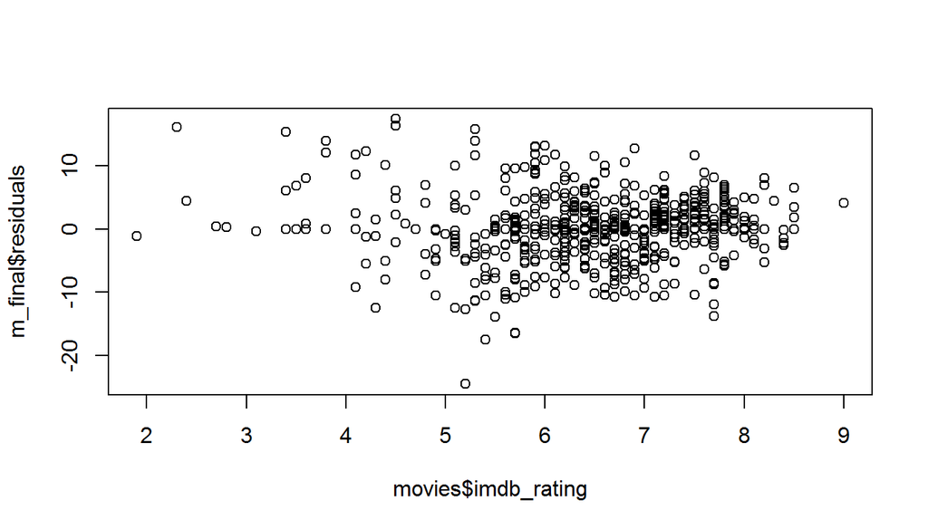

```r
movies<-movies %>%
  filter(is.na(studio)==F)

# since imdb_rating is the only explanatory variable
plot(m_final$residuals ~ movies$imdb_rating)
```

Since there is no pattern in distribution of residuals condition for linearity is established

2. Normality

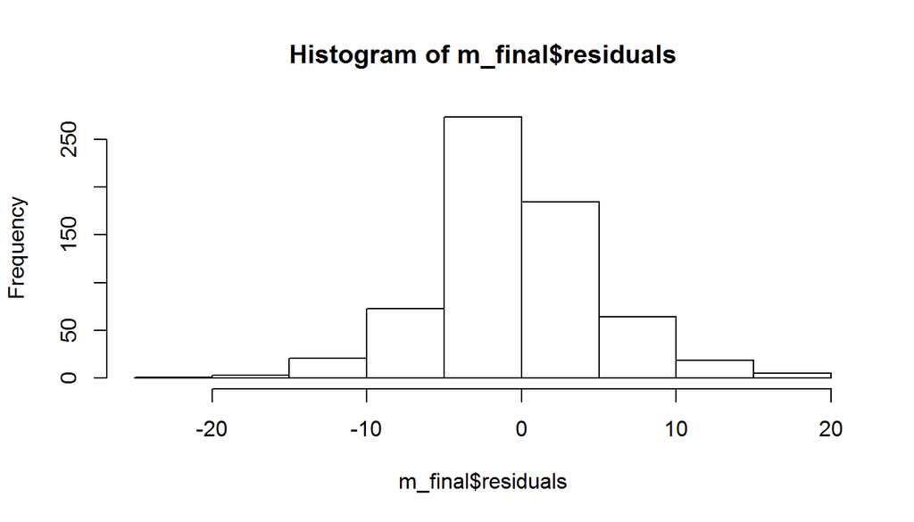

```r
hist(m_final$residuals)
```

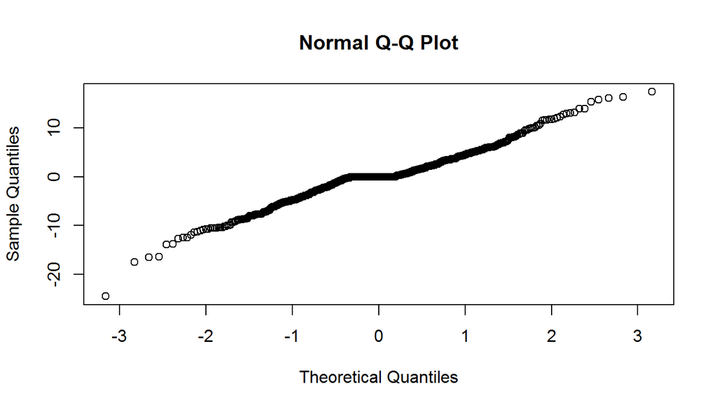

```r
qqnorm(m_final$residuals)
```

Since histogram is nearly normal with mean at 0 condition of noramlity is satisfied

3.Constant variability of residuals

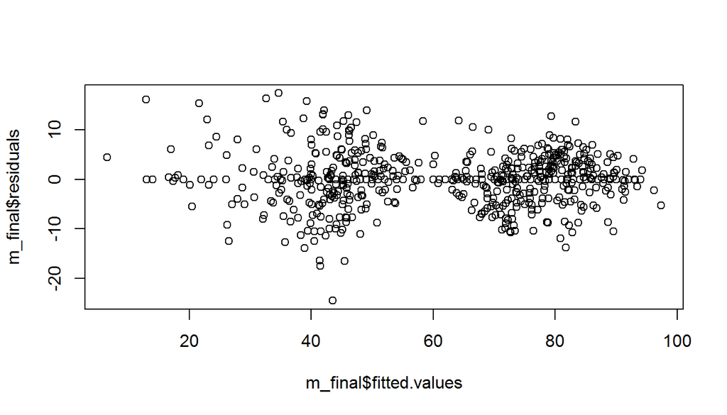

```r
plot(m_final$residuals ~ m_final$fitted.values)
```

Since there is no pattern in distirbution of residuals the condition of constant variability is met

4. Independence:

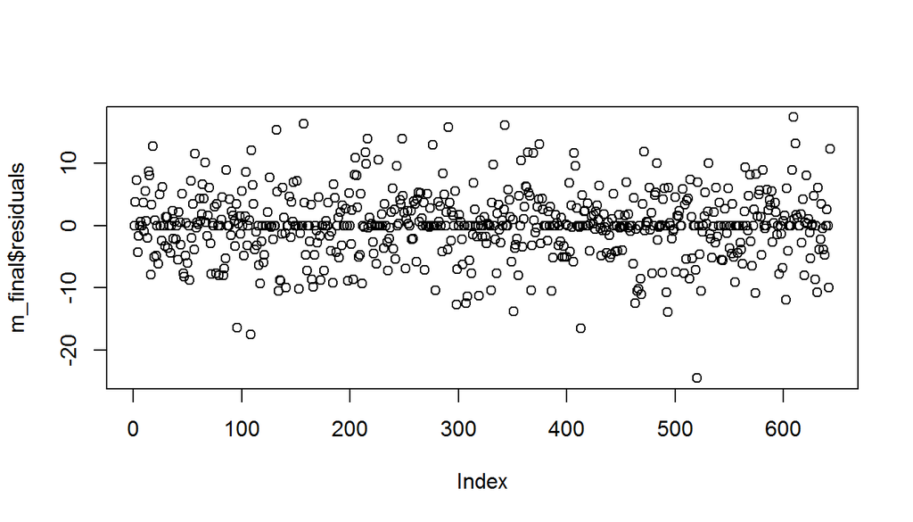

```r
plot(m_final$residuals)
```

So conditon of independence is met since distribution is random

## Part 5: Prediction

Predicting for the latest movie released in 2016

Movie name:SULLY ; audience rating= 82

```r
df=data.frame(studio="Warner Bros. Pictures",
              audience_rating="Upright",genre="Drama",
              imdb_rating=7.9,best_actress_win="no",
              thtr_rel_day=as.factor(8))
predict(m_final,df)
```

```
##        1
## 82.70889
```

The Predicted audience score is 82.7 which is very close to actual score of 82

```r
predict(m_final,df,interval="prediction",level=0.95)
```

```
##        fit    lwr      upr
## 1 82.70889 68.814 96.60378
```

## Part 6: Conclusion

Some findings from this data and modelling exercise are :

3.A shortcoming of this method is low number of samples for each genre

4.A future study can be done based upon how the difference in audience and critics rating vary according to genre